# Getting started with functions

- Functions name
- Functions body
- input(dynamic) parameters

## 1. Define and Call functions

```python
def my_max(x,y):
    z = x if x>y else y
    return z

def say_hi(name):
    print('===executed say_hi function===')
    return 'Hello ' + name

a = 6
b = 9

result = my_max(a,b)
print('result:',result)
print(say_hi('Jack'))
```

```
result: 9
===executed say_hi function===
Hello Jack
```

## 2. Provide docstring to functions

Using the following method to get access to the documents of functions

- `help()`
- `function.__doc__`

```python
def my_max(x,y):
    '''
    get the bigger number between 2 numbers
    my_max(x,y)
        return the larger number between x and y
    '''
    z = x if x > y else y
    return z

help(my_max)
print(my_max.__doc__)
```

```
Help on function my_max in module __main__:

my_max(x, y)
    get the bigger number between 2 numbers
    my_max(x,y)
        return the larger number between x and y


    get the bigger number between 2 numbers
    my_max(x,y)
        return the larger number between x and y
```

## 3. Multiple Returns

- Python would automatically transfer them into a `tuple`

```python
def sum_and_avg(list):
    my_sum = 0
    count = 0
    for e in list:
        if isinstance(e,int) or isinstance(e,float):
            count += 1
            my_sum += e
    return my_sum, my_sum / count

my_list = [20,15,2.8,'a',35,5.9,-1.8]
tp = sum_and_avg(my_list)
print(tp)
```

```
(76.9, 12.816666666666668)
```

```python
s,avg = sum_and_avg(my_list)
print(s)
print(avg)
```

```
76.9
12.816666666666668
```

## 4. Recursive Function

$f(0) = 1, f(1) = 4 , f(n+2) = 2 * f(n+1) + f(n)$

```python
def fn(n):
    if n == 0:
        return 1
    elif n == 1:
        return 4
    else:
        return 2 * fn(n-1) + fn(n-2)

print('f(10) = ', fn(10))
```

```
f(10) =  10497
```

**Tower of Hanoi**

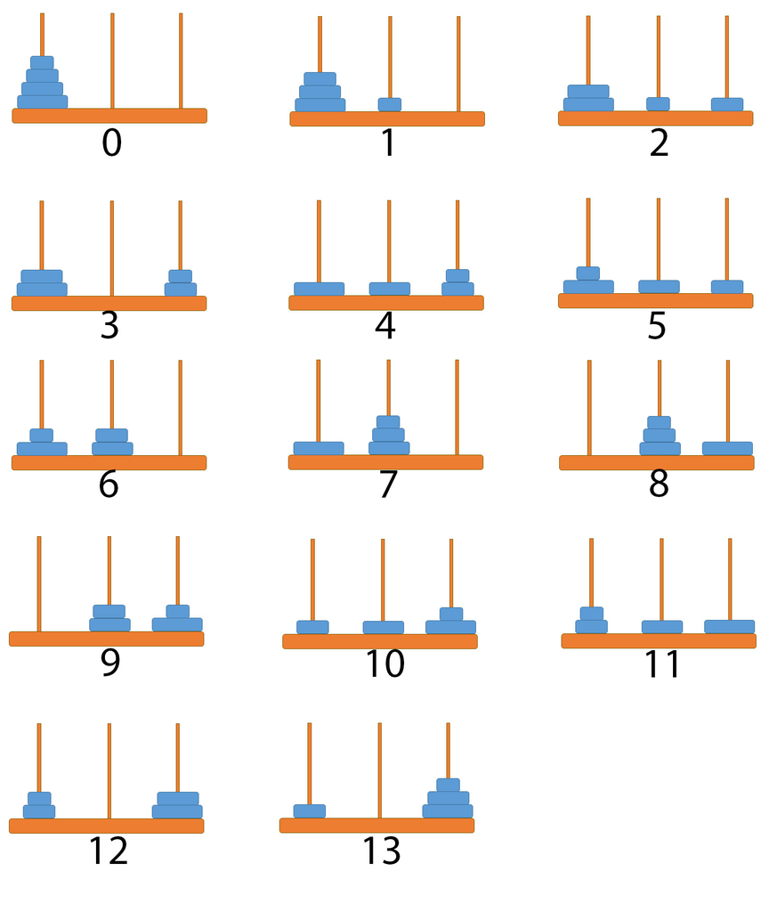

```python
def hanoi(n,x,y,z):
    '''
    x indicates the source block, y indicates the empty block, z indicates the target block
    '''
    if n == 1:
        print(x,'-->',z)
    else:
        hanoi(n-1,x,z,y)
        print(x,'-->',z)
        hanoi(n-1,y,x,z)
```

```python
hanoi(2,'1','2','3')
```

```
1 --> 2
1 --> 3
2 --> 3
```

```python
def factorial(n):
    if n <= 1:
        return 1
    else:
        return n * factorial(n-1)
```

```python
factorial(4)
factorial(5)
factorial(6)
```

```
720
```

## 5. Multiple input parameters

- No keyword multiple inputs could be regarded as a tuple
- Multiple inputs with keywords would be regarded as a dictionary

```python
def test(a,*books):
    print(books)
    for b in books:
        print(b)
    print(a)

test(5,'Crazy Java','Crazy Python','Crazy PHP')
```

```
('Crazy Java', 'Crazy Python', 'Crazy PHP')
Crazy Java
Crazy Python
Crazy PHP
5
```

```python
def test(*books,num):
    print(books)
    for b in books:
        print(b)
    print(num)
test('Crazy Python','Crazy Java','Crazy PHP',num = 20)
```

```
('Crazy Python', 'Crazy Java', 'Crazy PHP')
Crazy Python
Crazy Java
Crazy PHP
20
```

```python
def test(x,y,z=3,*books,**scores):
    print(x,y,z)
    print(books)
    print(scores)

test(1,2,3,'Crazy Java','Crazy Python', English = 94, Math = 89)
```

```
1 2 3
('Crazy Java', 'Crazy Python')
{'English': 94, 'Math': 89}
```

```python
test(1,2,'Crazy Java','Crazy Python', English = 94, Math = 89)
```

```
1 2 Crazy Java
('Crazy Python',)
{'English': 94, 'Math': 89}
```

```python
test(1,2, English = 94, Math = 89)
```

```
1 2 3
()
{'English': 94, 'Math': 89}
```

## 6. Reversed parameters input

```python
def test(name,message):
    print('User Name:',name)
    print('Message is',message)

my_list = ['Jack','Where is my shoes?']
test(*my_list)
```

```
User Name: Jack
Message is Where is my shoes?
```

```python
def foo(name,*nums):
    print('Name is',name)
    print('Number is',nums)

my_tuple = (1,2,3)
foo('fkit',*my_tuple)
```

```
Name is fkit
Number is (1, 2, 3)
```

```python
foo(*my_tuple)
```

```
Name is 1
Number is (2, 3)
```

```python
foo(my_tuple)
```

```
Name is (1, 2, 3)
Number is ()
```

**Dictionary also support for reversed input**

```python
def bar(book,price,desc):
    print(book, 'With the price of', price)
    print('Description is',desc)

my_dict = {'price':89,'book':'Crazy Python','desc':'This is a book for teaching how to use python'}
bar(**my_dict)
```

```
Crazy Python With the price of 89
Description is This is a book for teaching how to use python
```

## 7. Parameter passing mechanism

**In python, parameters for functions are passing by value**

```python
def swap(a,b):
    a,b = b,a
    print('Within swap function, a is',a,'b is',b)

a = 6
b = 9
swap(a,b)
print('After swap function, a is',a,'b is',b)
```

```
Within swap function, a is 9 b is 6
After swap function, a is 6 b is 9
```

**Careful for inputting list or dictionary**  
It is also passing by value, but this value is a address index, so the outputs would be changed

```python
def swap(dw):
    dw['a'],dw['b'] = dw['b'],dw['a']
    print('Within swap function, a is',dw['a'],'b is',dw['b'])

dw = {'a':6,'b':9}
swap(dw)
print('After swap function,  a is',dw['a'],'b is',dw['b'])
```

```
Within swap function, a is 9 b is 6
After swap function,  a is 9 b is 6
```

## 8. The work domain of Variables

All three functions would pack the variables into a dictionary

- `globals()`: Return all variabls
- `locals()`: Return variables within a local domain
- `vars(object)`: Return variables within a object domain

**Only the change in the global dictionary would be saved**

```python
def test():
    age = 20
    print(age)
    print(locals())
    print(locals()['age'])
    locals()['age'] = 12
    print('After changing through locals(), age is',age)

    globals()['x'] = 19

x = 5
y = 20
# print(globals())
# print(locals())
print('3',x)
print('4',globals()['x'])
globals()['x'] = 39
print('5',x)
locals()['x'] = 99
print('6',x)
test()
```

```
3 5
4 5
5 39
6 99
20
{'age': 20}
20
After changing through locals(), age is 20
```

#### **Variabls outsides of functions would be regarded as global variabls**

But we could not **modify their value within** the functions

```python
name = 'Jack'
def test():
    print(name)
test()
print(name)
```

```
Jack
Jack
```

```python
name = 'Jack'
def test():
    print(globals()['name'])
    name = 'Betty'
test()
print(name)
```

```
Jack
Jack
```

#### But we still could define a global variable within a function

```python
name = 'Jack'
def test():
    global name
    print(name)
    name = 'Betty'

test()
print(name)
```

```
Jack
Betty
```

## 9. Local Functions

- In default, local functions are hidden for outsides, only work within the enclosing domain.
- We could **return the local function** to call it in outsides

```python
def get_math_func(types,nn):
    def square(n):
        return n*n
    def cube(n):
        return n*n*n
    def factorial(n):
        if n <= 1:
            return 1
        else:
            return n * factorial(n-1)
    if types == 'square':
        return square(nn)
    elif types == 'cube':
        return cube(nn)
    else:
        return factorial(nn)

print(get_math_func('square',3))
print(get_math_func('cube',3))
print(get_math_func('',3))
```

```
9
27
6
```

#### Python provide `nonlocal` to acess local variables with the enclosing domain for local functions

```python
def foo():
    name = 'Jack'
    def bar():
        nonlocal name
        print(name)
        name = 'Betty'
    bar()
    print(name)

foo()
```

```
Jack
Betty
```